# R Notebook

PARTE 1 Iniciamos el trabajo cargando las librerías que vamos a utilizar.

```r
library(tidyverse)
library(rvest)
library(geosphere)
library(ggplot2)
library(stringr)
library(scales)
```

Empezamos cargando los datasets con la información de los vuelos entre los años 2014-2020.

```r
#Creamos una lista con los csv, le aplicamos la función read.csv y luego juntamos cada csv de la lista con la función bind_rows.
vuelos_df <- list.files(path = "./csvfiles", pattern = '*.csv', full.names = TRUE) %>%
  lapply(read.csv, sep = ";") %>%
  bind_rows

head(vuelos_df)
```

|  | Fecha | Hora | Clase.de.Vuelo | Clasificación.Vuelo | Tipo.de.Movimiento | Origen.OACI | Destino.OACI | Aerolinea.Nombre | Aeronave |
| --- | --- | --- | --- | --- | --- | --- | --- | --- | --- |
| 1 | 01/01/2014 | 1 | No Regular | Cabotaje | Aterrizaje | SAME | SACO | SOL Líneas Aéreas | SAAB SF34 |
| 2 | 01/01/2014 | 1 | Regular | Internacional | Despegue | SABE | SBGR | Gol Transportes Aéreo | BOEING B-737 |
| 3 | 01/01/2014 | 1 | Regular | Cabotaje | Aterrizaje | SASJ | SABE | Austral Líneas Aéreas | EMBRAER E-190 |
| 4 | 01/01/2014 | 1 | Regular | Cabotaje | Aterrizaje | SABE | SACO | Austral Líneas Aéreas | EMBRAER E-190 |
| 5 | 01/01/2014 | 1 | Regular | Internacional | Despegue | SAEZ | KIAH | United Airlines | BOEING B-767 |
| 6 | 01/01/2014 | 1 | Regular | Internacional | Aterrizaje | SBGR | SAEZ | Turkish Airlines | AIRBUS A-340 |

Vemos que tenemos una columna con las fechas de los vuelos pero en formato character, por lo tanto la transformamos en formato `Date`. Esto nos va a resultar muy útil mas adelante. Filtramos también los vuelos internacionales para quedarnos únicamente con los nacionales.

```r
#Convertimos a formato Date la columna Fechas
vuelos_df$Fecha = as.Date(vuelos_df$Fecha,format="%d/%m/%Y")


#Limpiamos la columna "Clasificación.Vuelo"

vuelos_df$Clasificación.Vuelo = gsub(' ', '', vuelos_df$Clasificación.Vuelo, fixed = TRUE)

#Filtramos por vuelos nacionales
vuelos_df <- vuelos_df %>%
  filter(Clasificación.Vuelo == "Cabotaje")
```

Veamos como queda nuestro dataframe

```r
head(vuelos_df)
```

|  | Fecha | Hora | Clase.de.Vuelo | Clasificación.Vuelo | Tipo.de.Movimiento | Origen.OACI | Destino.OACI | Aerolinea.Nombre | Aeronave |
| --- | --- | --- | --- | --- | --- | --- | --- | --- | --- |
| 1 | 2014-01-01 | 1 | No Regular | Cabotaje | Aterrizaje | SAME | SACO | SOL Líneas Aéreas | SAAB SF34 |
| 2 | 2014-01-01 | 1 | Regular | Cabotaje | Aterrizaje | SASJ | SABE | Austral Líneas Aéreas | EMBRAER E-190 |
| 3 | 2014-01-01 | 1 | Regular | Cabotaje | Aterrizaje | SABE | SACO | Austral Líneas Aéreas | EMBRAER E-190 |
| 4 | 2014-01-01 | 1 | Regular | Cabotaje | Aterrizaje | SAWC | SABE | Aerolíneas Argentinas | BOEING B-737 |
| 5 | 2014-01-01 | 1 | Regular | Cabotaje | Aterrizaje | SASA | SARI | Austral Líneas Aéreas | EMBRAER E-190 |
| 6 | 2014-01-01 | 1 | Regular | Cabotaje | Despegue | SACO | SAAR | SOL Líneas Aéreas | SAAB SF34 |

El siguiente paso es agregarle a nuesto dataframe las variables ciudad, provincia y coordenadas a cada vuelo. Veamos que columnas trae nuestro df

```r
colnames(vuelos_df)
```

```
[1] "Fecha"               "Hora"                "Clase.de.Vuelo"      "Clasificación.Vuelo" "Tipo.de.Movimiento"  "Origen.OACI"         "Destino.OACI"
[8] "Aerolinea.Nombre"    "Aeronave"
```

Vemos que tenemos dos variables llamadas Origen.OACI y Destino.OACI, buscando en internet, encontramos la definicion de OACI como: *“La Organización de Aviación Civil Internacional (OACI), organismo especializado de las Naciones Unidas, se creó con la firma en Chicago, el 7 de diciembre de 1944, del Convenio sobre Aviación Civil Internacional. La OACI es el órgano permanente encargado de la administración de los principios establecidos en el Convenio.”* Basicamente podemos usar el OACI como un código para la identificacion de un aeropuerto. Tenemos en nuestro caso Origen.OACI y Destino.OACI, por lo que debemos agregar ciudad, provincia y localizacion del aeropuerto de origen y de destino.

Primero que nada obtengamos la información, en este caso de nuestra amiga wikipedia.

```r
#Importamos la información de las ciudades, provincias y coordenadas desde wikipedia.
LIST_OF_AIRPORTS_WIKIPEDIA_URL = read_html('https://en.wikipedia.org/wiki/List_of_airports_in_Argentina')
elem_tabla = html_element(LIST_OF_AIRPORTS_WIKIPEDIA_URL, ".wikitable")
aeropuertos_df = html_table(elem_tabla)
aeropuertos_df
```

| City served | Province | ICAO | IATA | Airport name | Coordinates |
| --- | --- | --- | --- | --- | --- |
| Alto Río Senguer | Chubut | SAVR | ARR | Alto Río Senguer Airport | .mw-parser-output .geo-default,.mw-parser-output .geo-dms,.mw-parser-output .geo-dec{display:inline}.mw-parser-output .geo-nondefault,.mw-parser-output .geo-multi-punct{display:none}.mw-parser-output … |
| Ascochinga | Córdoba | SACN |  | Ascochinga Airport | 30°59'25"S 064°14'39"W / 30.99028°S 64.24417°W / -30.99028; -64.24417 (Ascochinga Airport (Ascochinga)) |
| Azul | Buenos Aires | SAZA |  | Azul Airport | 36°50'14"S 059°52'51"W / 36.83722°S 59.88083°W / -36.83722; -59.88083 (Aeródromo de Azul (Azul)) |
| Bahía Blanca | Buenos Aires | SAZB | BHI | Comandante Espora Airport | 38°43'29"S 062°10'09"W / 38.72472°S 62.16917°W / -38.72472; -62.16917 (Comandante Espora Airport) |
| Bariloche | Río Negro | SAZS | BRC | San Carlos de Bariloche Airport | 41°09'04"S 071°09'27"W / 41.15111°S 71.15750°W / -41.15111; -71.15750 (Teniente Luis Candelaria International Airport) |
| Benito Juárez | Buenos Aires | SAZJ |  | Benito Juárez Airport | 37°42'22"S 059°47'31"W / 37.70611°S 59.79194°W / -37.70611; -59.79194 (Benito Juárez Airport (Benito Juárez)) |
| Bernardo de Irigoyen | Misiones | SATI |  | Bernardo de Irigoyen Airport | 26°15'00"S 053°37'46"W / 26.25000°S 53.62944°W / -26.25000; -53.62944 (Bernardo de Irigoyen Airport (Bernardo de Irigoyen)) |
| Bolívar (San Carlos de Bolívar) | Buenos Aires | SAZI |  | Bolívar Airport | 36°11'11"S 061°04'34"W / 36.18639°S 61.07611°W / -36.18639; -61.07611 (Bolívar Airport) |
| Buenos Aires metropolitan area | Buenos Aires | SABE | AEP | Aeroparque Jorge Newbery | 34°33'33"S 058°24'57"W / 34.55917°S 58.41583°W / -34.55917; -58.41583 (Jorge Newbery Airfield (Buenos Aires)) |
| Buenos Aires metropolitan area | Buenos Aires | SADP | EPA | El Palomar Airport | 34°36'35"S 058°36'45"W / 34.60972°S 58.61250°W / -34.60972; -58.61250 (El Palomar Airport) |

[output cut: 157 more lines]

Bien ya tenemos la tabla scrappeada de wikipedia, ahora debemos buscar una manera de agregar a nuestro `vuelos_df` las columnas ciudad, provincia y latitud y longitud. Como tenemos la columnas ICAO, podemos usarla para identificar aeropuertos en nuestro dataframe.

Antes de realizar el matcheo de los dataframes, veamos si no hay algún incoveniente con los elementos de las columnas relevantes en este caso. Analizando en detalle la columna de destino del dataframe `vuelos_df` pudimos observar que hay elementos con espacios en blanco, como por ejemplo:

```r
vuelos_df$Destino.OACI[3]
```

```
[1] "SACO   "
```

Esto hay que corregirlo antes de agregar las nuevas columnas ya que el matcheo dificilmente funcione si los elementos de las columnas no coinciden. Limpiamos entonces los elementos de las columnas que vamos a usar:

```r
#Borramos todo lo que no sean letras:
vuelos_df$Origen.OACI = gsub('[^A-Z,]', '', vuelos_df$Origen.OACI, fixed = TRUE)
vuelos_df$Origen.OACI = gsub(' ', '', vuelos_df$Origen.OACI, fixed = TRUE)

vuelos_df$Destino.OACI = gsub('[^A-Z,]', '', vuelos_df$Destino.OACI, fixed = TRUE)
vuelos_df$Destino.OACI = gsub(' ', '', vuelos_df$Destino.OACI, fixed = TRUE)

aeropuertos_df$ICAO = gsub('[^A-Z,]', '', aeropuertos_df$ICAO, fixed = TRUE)
aeropuertos_df$ICAO = gsub(' ', '', aeropuertos_df$ICAO, fixed = TRUE)
```

Veamos si esto funcionó correctamente:

```r
vuelos_df$Destino.OACI[3]
```

```
[1] "SACO"
```

Efectivamente borramos los espacios en blanco de las variables relevantes. Ahora podemos hacer el matcheo de los dataframes, empezando por cargar la información de la tabla de aeropuertos referidos a los códigos de `Origen.ICAO`. Para ello usamos la función `left_join`.

```r
vuelos_df_joined = left_join(vuelos_df, aeropuertos_df, by=c('Origen.OACI' = 'ICAO'))
```

Veamos como quedó:

```r
head(vuelos_df_joined)
```

|  | Fecha | Hora | Clase.de.Vuelo | Clasificación.Vuelo | Tipo.de.Movimiento | Origen.OACI | Destino.OACI | Aerolinea.Nombre | Aeronave | City served | Province | IATA | Airport name | Coordinates |
| --- | --- | --- | --- | --- | --- | --- | --- | --- | --- | --- | --- | --- | --- | --- |
| 1 | 2014-01-01 | 1 | No Regular | Cabotaje | Aterrizaje | SAME | SACO | SOL Líneas Aéreas | SAAB SF34 | Mendoza | Mendoza | MDZ | Governor Francisco Gabrielli International Airport(El Plumerillo International Airport) | 32°49'54"S 68°47'34"W / 32.83167°S 68.79278°W / -32.83167; -68.79278 (Governor Francisco Gabrielli International Airport) |
| 2 | 2014-01-01 | 1 | Regular | Cabotaje | Aterrizaje | SASJ | SABE | Austral Líneas Aéreas | EMBRAER E-190 | Jujuy (San Salvador de Jujuy) | Jujuy | JUJ | Gobernador Horacio Guzmán International Airport | 24°23'34"S 065°05'52"W / 24.39278°S 65.09778°W / -24.39278; -65.09778 (Gobernador Horacio Guzmán International Airport) |
| 3 | 2014-01-01 | 1 | Regular | Cabotaje | Aterrizaje | SABE | SACO | Austral Líneas Aéreas | EMBRAER E-190 | Buenos Aires metropolitan area | Buenos Aires | AEP | Aeroparque Jorge Newbery | 34°33'33"S 058°24'57"W / 34.55917°S 58.41583°W / -34.55917; -58.41583 (Jorge Newbery Airfield (Buenos Aires)) |
| 4 | 2014-01-01 | 1 | Regular | Cabotaje | Aterrizaje | SAWC | SABE | Aerolíneas Argentinas | BOEING B-737 | El Calafate | Santa Cruz | FTE | Comandante Armando Tola International Airport | 50°16'49"S 072°03'11"W / 50.28028°S 72.05306°W / -50.28028; -72.05306 (Comandante Armando Tola International Airport) |
| 5 | 2014-01-01 | 1 | Regular | Cabotaje | Aterrizaje | SASA | SARI | Austral Líneas Aéreas | EMBRAER E-190 | Salta | Salta | SLA | Martín Miguel de Güemes International Airport(El Aybal Airport) | 24°51'21"S 065°29'10"W / 24.85583°S 65.48611°W / -24.85583; -65.48611 (Martín Miguel de Güemes Airport (El Aybal Airport)) |
| 6 | 2014-01-01 | 1 | Regular | Cabotaje | Despegue | SACO | SAAR | SOL Líneas Aéreas | SAAB SF34 | Córdoba | Córdoba | COR | Ing. Aer. Ambrosio L.V. Taravella International Airport | 31°19'25"S 064°12'28"W / 31.32361°S 64.20778°W / -31.32361; -64.20778 (Ing. Aer. Ambrosio L.V. Taravella Airport) |

Como vemos se agregaron las columnas que buscamos pero tenemos que limpiarlas un poco. Vamos a mejorar un poco la columna coordenadas, tiene mucha información que no nos interesa por ahora.

```r
#elimino todo lo que esta antes de /
vuelos_df_joined$Coordinates = gsub(".*/", "", vuelos_df_joined$Coordinates)
#elimino todo lo que viene despues del parentesis
vuelos_df_joined$Coordinates = gsub("\\(.*", "", vuelos_df_joined$Coordinates)
#elimino los espacios en blanco
vuelos_df_joined$Coordinates = gsub(" ", "", vuelos_df_joined$Coordinates, fixed = TRUE)
#Eliminos los "<U+FEFF>"
vuelos_df_joined$Coordinates = gsub("\\xef\\xbb\\xbf", "", vuelos_df_joined$Coordinates, useBytes = T)
```

Veamos como va quedando:

```r
head(vuelos_df_joined)
```

|  | Fecha | Hora | Clase.de.Vuelo | Clasificación.Vuelo | Tipo.de.Movimiento | Origen.OACI | Destino.OACI | Aerolinea.Nombre | Aeronave | City served | Province | IATA | Airport name | Coordinates |
| --- | --- | --- | --- | --- | --- | --- | --- | --- | --- | --- | --- | --- | --- | --- |
| 1 | 2014-01-01 | 1 | No Regular | Cabotaje | Aterrizaje | SAME | SACO | SOL Líneas Aéreas | SAAB SF34 | Mendoza | Mendoza | MDZ | Governor Francisco Gabrielli International Airport(El Plumerillo International Airport) | -32.83167;-68.79278 |
| 2 | 2014-01-01 | 1 | Regular | Cabotaje | Aterrizaje | SASJ | SABE | Austral Líneas Aéreas | EMBRAER E-190 | Jujuy (San Salvador de Jujuy) | Jujuy | JUJ | Gobernador Horacio Guzmán International Airport | -24.39278;-65.09778 |
| 3 | 2014-01-01 | 1 | Regular | Cabotaje | Aterrizaje | SABE | SACO | Austral Líneas Aéreas | EMBRAER E-190 | Buenos Aires metropolitan area | Buenos Aires | AEP | Aeroparque Jorge Newbery | -34.55917;-58.41583 |
| 4 | 2014-01-01 | 1 | Regular | Cabotaje | Aterrizaje | SAWC | SABE | Aerolíneas Argentinas | BOEING B-737 | El Calafate | Santa Cruz | FTE | Comandante Armando Tola International Airport | -50.28028;-72.05306 |
| 5 | 2014-01-01 | 1 | Regular | Cabotaje | Aterrizaje | SASA | SARI | Austral Líneas Aéreas | EMBRAER E-190 | Salta | Salta | SLA | Martín Miguel de Güemes International Airport(El Aybal Airport) | -24.85583;-65.48611 |
| 6 | 2014-01-01 | 1 | Regular | Cabotaje | Despegue | SACO | SAAR | SOL Líneas Aéreas | SAAB SF34 | Córdoba | Córdoba | COR | Ing. Aer. Ambrosio L.V. Taravella International Airport | -31.32361;-64.20778 |

Ahora que ya tenemos nuestras coordenadas, vamos a pasarlas a una columna para latitud y otra longitud

```r
# Spliteamos el string de coordenadas en dos columnas "Latitud origen" y "Latitud destino"
vuelos_df_joined$Latitud_origen = str_split_fixed(vuelos_df_joined$Coordinates, ";", 2)[,1]
vuelos_df_joined$Longitud_origen = str_split_fixed(vuelos_df_joined$Coordinates, ";", 2)[,2]
```

Revisemos como quedó:

```r
head(vuelos_df_joined)
```

|  | Fecha | Hora | Clase.de.Vuelo | Clasificación.Vuelo | Tipo.de.Movimiento | Origen.OACI | Destino.OACI | Aerolinea.Nombre | Aeronave | City served | Province | IATA | Airport name | Coordinates | Latitud_origen | Longitud_origen |
| --- | --- | --- | --- | --- | --- | --- | --- | --- | --- | --- | --- | --- | --- | --- | --- | --- |
| 1 | 2014-01-01 | 1 | No Regular | Cabotaje | Aterrizaje | SAME | SACO | SOL Líneas Aéreas | SAAB SF34 | Mendoza | Mendoza | MDZ | Governor Francisco Gabrielli International Airport(El Plumerillo International Airport) | -32.83167;-68.79278 | -32.83167 | -68.79278 |
| 2 | 2014-01-01 | 1 | Regular | Cabotaje | Aterrizaje | SASJ | SABE | Austral Líneas Aéreas | EMBRAER E-190 | Jujuy (San Salvador de Jujuy) | Jujuy | JUJ | Gobernador Horacio Guzmán International Airport | -24.39278;-65.09778 | -24.39278 | -65.09778 |
| 3 | 2014-01-01 | 1 | Regular | Cabotaje | Aterrizaje | SABE | SACO | Austral Líneas Aéreas | EMBRAER E-190 | Buenos Aires metropolitan area | Buenos Aires | AEP | Aeroparque Jorge Newbery | -34.55917;-58.41583 | -34.55917 | -58.41583 |
| 4 | 2014-01-01 | 1 | Regular | Cabotaje | Aterrizaje | SAWC | SABE | Aerolíneas Argentinas | BOEING B-737 | El Calafate | Santa Cruz | FTE | Comandante Armando Tola International Airport | -50.28028;-72.05306 | -50.28028 | -72.05306 |
| 5 | 2014-01-01 | 1 | Regular | Cabotaje | Aterrizaje | SASA | SARI | Austral Líneas Aéreas | EMBRAER E-190 | Salta | Salta | SLA | Martín Miguel de Güemes International Airport(El Aybal Airport) | -24.85583;-65.48611 | -24.85583 | -65.48611 |
| 6 | 2014-01-01 | 1 | Regular | Cabotaje | Despegue | SACO | SAAR | SOL Líneas Aéreas | SAAB SF34 | Córdoba | Córdoba | COR | Ing. Aer. Ambrosio L.V. Taravella International Airport | -31.32361;-64.20778 | -31.32361 | -64.20778 |

Ahora renombremos las columnas, para aclarar las que son de origen, ya que agregaremos luego las columnas referidas a los destinos del vuelo.

```r
vuelos_df_joined = vuelos_df_joined %>%
    rename(
      Coordenadas_origen = Coordinates,
      Aeropuerto_origen = `Airport name`,
      Provincia_origen = Province,
      Ciudad_origen = `City served`,
      IATA_origen = IATA
    )
```

Ya que estamos modificando los nombres de columnas, modifiquemos algunas columnas más que todavía no utilizamos, porque seguramente necesitemos hacerlo en el futuro.

```r
vuelos_df_joined = vuelos_df_joined %>%
    rename(
      Clase_de_vuelo = Clase.de.Vuelo,
      Tipo_de_vuelo = Clasificación.Vuelo ,
      Tipo_de_movimiento = Tipo.de.Movimiento,
      Nombre_de_aereolinea = Aerolinea.Nombre,
    )
```

Veamos como va quedando nuestro dataframe:

```r
head(vuelos_df_joined)
```

|  | Fecha | Hora | Clase_de_vuelo | Tipo_de_vuelo | Tipo_de_movimiento | Origen.OACI | Destino.OACI | Nombre_de_aereolinea | Aeronave | Ciudad_origen | Provincia_origen | IATA_origen | Aeropuerto_origen | Coordenadas_origen | Latitud_origen | Longitud_origen |
| --- | --- | --- | --- | --- | --- | --- | --- | --- | --- | --- | --- | --- | --- | --- | --- | --- |
| 1 | 2014-01-01 | 1 | No Regular | Cabotaje | Aterrizaje | SAME | SACO | SOL Líneas Aéreas | SAAB SF34 | Mendoza | Mendoza | MDZ | Governor Francisco Gabrielli International Airport(El Plumerillo International Airport) | -32.83167;-68.79278 | -32.83167 | -68.79278 |
| 2 | 2014-01-01 | 1 | Regular | Cabotaje | Aterrizaje | SASJ | SABE | Austral Líneas Aéreas | EMBRAER E-190 | Jujuy (San Salvador de Jujuy) | Jujuy | JUJ | Gobernador Horacio Guzmán International Airport | -24.39278;-65.09778 | -24.39278 | -65.09778 |
| 3 | 2014-01-01 | 1 | Regular | Cabotaje | Aterrizaje | SABE | SACO | Austral Líneas Aéreas | EMBRAER E-190 | Buenos Aires metropolitan area | Buenos Aires | AEP | Aeroparque Jorge Newbery | -34.55917;-58.41583 | -34.55917 | -58.41583 |
| 4 | 2014-01-01 | 1 | Regular | Cabotaje | Aterrizaje | SAWC | SABE | Aerolíneas Argentinas | BOEING B-737 | El Calafate | Santa Cruz | FTE | Comandante Armando Tola International Airport | -50.28028;-72.05306 | -50.28028 | -72.05306 |
| 5 | 2014-01-01 | 1 | Regular | Cabotaje | Aterrizaje | SASA | SARI | Austral Líneas Aéreas | EMBRAER E-190 | Salta | Salta | SLA | Martín Miguel de Güemes International Airport(El Aybal Airport) | -24.85583;-65.48611 | -24.85583 | -65.48611 |
| 6 | 2014-01-01 | 1 | Regular | Cabotaje | Despegue | SACO | SAAR | SOL Líneas Aéreas | SAAB SF34 | Córdoba | Córdoba | COR | Ing. Aer. Ambrosio L.V. Taravella International Airport | -31.32361;-64.20778 | -31.32361 | -64.20778 |

Ahora que tenemos nuestros datos de origen, volvamos a hacer el proceso para los datos de destino:

```r
# vuelos_df_joined$Anio = str_split_fixed(vuelos_df_joined$Fecha, "-", 3)[,1]
```

Realizamos el `left_join` con la columna destino:

```r
vuelos_df_fully_joined = left_join(vuelos_df_joined, aeropuertos_df, by=c('Destino.OACI' = 'ICAO'))
```

Limpiamos la columna de las coordenadas de cada vuelo:

```r
#elimino todo lo que esta antes de /
vuelos_df_fully_joined$Coordinates = gsub(".*/", "", vuelos_df_fully_joined$Coordinates)
#elimino todo lo que viene despues del parentesis
vuelos_df_fully_joined$Coordinates = gsub("\\(.*", "", vuelos_df_fully_joined$Coordinates)
#elimino los espacios en blanco
vuelos_df_fully_joined$Coordinates = gsub(" ", "", vuelos_df_fully_joined$Coordinates, fixed = TRUE)
#Eliminos los "<U+FEFF>"
vuelos_df_fully_joined$Coordinates = gsub("\\xef\\xbb\\xbf", "", vuelos_df_fully_joined$Coordinates, useBytes = T)
```

Separamos nuevamente la columna coordenadas en Latitud y Longitud

```r
#Spliteamos la columna Coordinates en "Latitud_destino" y "Longitud_destino"
vuelos_df_fully_joined$Latitud_destino = str_split_fixed(vuelos_df_fully_joined$Coordinates, ";", 2)[,1]
vuelos_df_fully_joined$Longitud_destino = str_split_fixed(vuelos_df_fully_joined$Coordinates, ";", 2)[,2]
```

```r
head(vuelos_df_fully_joined)
```

|  | Fecha | Hora | Clase_de_vuelo | Tipo_de_vuelo | Tipo_de_movimiento | Origen.OACI | Destino.OACI | Nombre_de_aereolinea | Aeronave | Ciudad_origen | Provincia_origen | IATA_origen | Aeropuerto_origen | Coordenadas_origen | Latitud_origen | Longitud_origen | City served | Province | IATA | Airport name | Coordinates | Latitud_destino | Longitud_destino |
| --- | --- | --- | --- | --- | --- | --- | --- | --- | --- | --- | --- | --- | --- | --- | --- | --- | --- | --- | --- | --- | --- | --- | --- |
| 1 | 2014-01-01 | 1 | No Regular | Cabotaje | Aterrizaje | SAME | SACO | SOL Líneas Aéreas | SAAB SF34 | Mendoza | Mendoza | MDZ | Governor Francisco Gabrielli International Airport(El Plumerillo International Airport) | -32.83167;-68.79278 | -32.83167 | -68.79278 | Córdoba | Córdoba | COR | Ing. Aer. Ambrosio L.V. Taravella International Airport | -31.32361;-64.20778 | -31.32361 | -64.20778 |
| 2 | 2014-01-01 | 1 | Regular | Cabotaje | Aterrizaje | SASJ | SABE | Austral Líneas Aéreas | EMBRAER E-190 | Jujuy (San Salvador de Jujuy) | Jujuy | JUJ | Gobernador Horacio Guzmán International Airport | -24.39278;-65.09778 | -24.39278 | -65.09778 | Buenos Aires metropolitan area | Buenos Aires | AEP | Aeroparque Jorge Newbery | -34.55917;-58.41583 | -34.55917 | -58.41583 |
| 3 | 2014-01-01 | 1 | Regular | Cabotaje | Aterrizaje | SABE | SACO | Austral Líneas Aéreas | EMBRAER E-190 | Buenos Aires metropolitan area | Buenos Aires | AEP | Aeroparque Jorge Newbery | -34.55917;-58.41583 | -34.55917 | -58.41583 | Córdoba | Córdoba | COR | Ing. Aer. Ambrosio L.V. Taravella International Airport | -31.32361;-64.20778 | -31.32361 | -64.20778 |
| 4 | 2014-01-01 | 1 | Regular | Cabotaje | Aterrizaje | SAWC | SABE | Aerolíneas Argentinas | BOEING B-737 | El Calafate | Santa Cruz | FTE | Comandante Armando Tola International Airport | -50.28028;-72.05306 | -50.28028 | -72.05306 | Buenos Aires metropolitan area | Buenos Aires | AEP | Aeroparque Jorge Newbery | -34.55917;-58.41583 | -34.55917 | -58.41583 |
| 5 | 2014-01-01 | 1 | Regular | Cabotaje | Aterrizaje | SASA | SARI | Austral Líneas Aéreas | EMBRAER E-190 | Salta | Salta | SLA | Martín Miguel de Güemes International Airport(El Aybal Airport) | -24.85583;-65.48611 | -24.85583 | -65.48611 | Puerto Iguazú | Misiones | IGR | Cataratas del Iguazú International Airport(Mayor Carlos Eduardo Krause Airport) | -25.73722;-54.47333 | -25.73722 | -54.47333 |
| 6 | 2014-01-01 | 1 | Regular | Cabotaje | Despegue | SACO | SAAR | SOL Líneas Aéreas | SAAB SF34 | Córdoba | Córdoba | COR | Ing. Aer. Ambrosio L.V. Taravella International Airport | -31.32361;-64.20778 | -31.32361 | -64.20778 | Rosario | Santa Fe | ROS | Rosario – Islas Malvinas International Airport | -32.90361;-60.78500 | -32.90361 | -60.78500 |

Renombramos las columnas agregadas:

```r
#Renombro las columnas
vuelos_df_fully_joined = vuelos_df_fully_joined %>%
    rename(
      Coordenadas_destino = Coordinates,
      Aeropuerto_destino = `Airport name`,
      Provincia_destino = Province,
      Ciudad_destino = `City served`,
      IATA_destino = IATA
    )
```

Veamos como quedó el dataframe:

```r
head(vuelos_df_fully_joined)
```

|  | Fecha | Hora | Clase_de_vuelo | Tipo_de_vuelo | Tipo_de_movimiento | Origen.OACI | Destino.OACI | Nombre_de_aereolinea | Aeronave | Ciudad_origen | Provincia_origen | IATA_origen | Aeropuerto_origen | Coordenadas_origen | Latitud_origen | Longitud_origen | Ciudad_destino | Provincia_destino | IATA_destino | Aeropuerto_destino | Coordenadas_destino | Latitud_destino | Longitud_destino |
| --- | --- | --- | --- | --- | --- | --- | --- | --- | --- | --- | --- | --- | --- | --- | --- | --- | --- | --- | --- | --- | --- | --- | --- |
| 1 | 2014-01-01 | 1 | No Regular | Cabotaje | Aterrizaje | SAME | SACO | SOL Líneas Aéreas | SAAB SF34 | Mendoza | Mendoza | MDZ | Governor Francisco Gabrielli International Airport(El Plumerillo International Airport) | -32.83167;-68.79278 | -32.83167 | -68.79278 | Córdoba | Córdoba | COR | Ing. Aer. Ambrosio L.V. Taravella International Airport | -31.32361;-64.20778 | -31.32361 | -64.20778 |
| 2 | 2014-01-01 | 1 | Regular | Cabotaje | Aterrizaje | SASJ | SABE | Austral Líneas Aéreas | EMBRAER E-190 | Jujuy (San Salvador de Jujuy) | Jujuy | JUJ | Gobernador Horacio Guzmán International Airport | -24.39278;-65.09778 | -24.39278 | -65.09778 | Buenos Aires metropolitan area | Buenos Aires | AEP | Aeroparque Jorge Newbery | -34.55917;-58.41583 | -34.55917 | -58.41583 |
| 3 | 2014-01-01 | 1 | Regular | Cabotaje | Aterrizaje | SABE | SACO | Austral Líneas Aéreas | EMBRAER E-190 | Buenos Aires metropolitan area | Buenos Aires | AEP | Aeroparque Jorge Newbery | -34.55917;-58.41583 | -34.55917 | -58.41583 | Córdoba | Córdoba | COR | Ing. Aer. Ambrosio L.V. Taravella International Airport | -31.32361;-64.20778 | -31.32361 | -64.20778 |
| 4 | 2014-01-01 | 1 | Regular | Cabotaje | Aterrizaje | SAWC | SABE | Aerolíneas Argentinas | BOEING B-737 | El Calafate | Santa Cruz | FTE | Comandante Armando Tola International Airport | -50.28028;-72.05306 | -50.28028 | -72.05306 | Buenos Aires metropolitan area | Buenos Aires | AEP | Aeroparque Jorge Newbery | -34.55917;-58.41583 | -34.55917 | -58.41583 |
| 5 | 2014-01-01 | 1 | Regular | Cabotaje | Aterrizaje | SASA | SARI | Austral Líneas Aéreas | EMBRAER E-190 | Salta | Salta | SLA | Martín Miguel de Güemes International Airport(El Aybal Airport) | -24.85583;-65.48611 | -24.85583 | -65.48611 | Puerto Iguazú | Misiones | IGR | Cataratas del Iguazú International Airport(Mayor Carlos Eduardo Krause Airport) | -25.73722;-54.47333 | -25.73722 | -54.47333 |
| 6 | 2014-01-01 | 1 | Regular | Cabotaje | Despegue | SACO | SAAR | SOL Líneas Aéreas | SAAB SF34 | Córdoba | Córdoba | COR | Ing. Aer. Ambrosio L.V. Taravella International Airport | -31.32361;-64.20778 | -31.32361 | -64.20778 | Rosario | Santa Fe | ROS | Rosario – Islas Malvinas International Airport | -32.90361;-60.78500 | -32.90361 | -60.78500 |

Filtramos ahora los `NA` en las columnas coordenadas ya que mas adelante buscamos calcular distancias. Le asignamos un nuevo nombre a este dataframe con las coordenadas ya filtradas dado que probablemente la información de los dataframes anteriores nos sea útil también, es decir, no solo queremos ver qué ocurre con las distancias recorridas.

```r
#Limpiamos los NA's de las columnas coordenadas origen y destino
vuelos_coordenadas <- vuelos_df_fully_joined %>%
  filter(!is.na(vuelos_df_fully_joined$Coordenadas_origen),
         !is.na(vuelos_df_fully_joined$Coordenadas_destino)
  )
```

Armemos ahora la columna con las distancias recorridas. Para ello limpiamos primero las columnas relevantes:

```r
#limpiamos las columnas latitud y longitud
vuelos_coordenadas$Latitud_origen = gsub("[^0-9.-]", "", vuelos_coordenadas$Latitud_origen)
vuelos_coordenadas$Latitud_destino = gsub("[^0-9.-]", "", vuelos_coordenadas$Latitud_destino)
vuelos_coordenadas$Longitud_origen = gsub("[^0-9.-]", "", vuelos_coordenadas$Longitud_origen)
vuelos_coordenadas$Longitud_destino = gsub("[^0-9.-]", "", vuelos_coordenadas$Longitud_destino)

#Convertimos a numeric las columnas latitud y longitud
vuelos_coordenadas$Latitud_origen = as.numeric(vuelos_coordenadas$Latitud_origen)
vuelos_coordenadas$Longitud_origen = as.numeric(vuelos_coordenadas$Longitud_origen)
vuelos_coordenadas$Latitud_destino = as.numeric(vuelos_coordenadas$Latitud_destino)
vuelos_coordenadas$Longitud_destino = as.numeric(vuelos_coordenadas$Longitud_destino)
```

Calculamos ahora entonces la distancia recorrida en km por cada vuelo:

```r
#Calculamos la distancia recorrida con la función distHaversine.
vuelos_coordenadas = vuelos_coordenadas %>%
    mutate(Distancia_recorrida_km = distHaversine(cbind(Longitud_origen, Latitud_origen), cbind(Longitud_destino, Latitud_destino))/1000)
```

Hagamos un breve análisis estadístico sobre la distancia recorrida para ver si tiene sentido lo que obtuvimos:

```r
#Hago un análisis de estadístico de las distancias
summary(vuelos_coordenadas$Distancia_recorrida_km)
```

```
   Min. 1st Qu.  Median    Mean 3rd Qu.    Max.
    0.0   517.6   962.2   895.3  1272.1  3431.8
```

Vemos que el máximo de distancia tiene sentido ya que existen rutas aereas con distancias de 3500km dentro de argentina. El problema es que aparecen mínimos con distancia 0km. Limpiemos esos vuelos:

```r
#Filtro las distancias nulas
vuelos_coordenadas <- vuelos_coordenadas %>%
  filter(Distancia_recorrida_km != 0)
```

Otra cosa que podemos hacer separar la columna de fechas en día, mes y año para poder hacer mas adelante un análisis sobre cada una de estas variables:

```r
#Spliteamos la columna fecha en dias, mes y año
vuelos_coordenadas$Dia = str_split_fixed(vuelos_coordenadas$Fecha, "-", 3)[,3]
vuelos_coordenadas$Mes = str_split_fixed(vuelos_coordenadas$Fecha, "-", 3)[,2]
vuelos_coordenadas$Anio = str_split_fixed(vuelos_coordenadas$Fecha, "-", 3)[,1]
```

Vemos como quedó el dataframe

```r
head(vuelos_coordenadas)
```

|  | Fecha | Hora | Clase_de_vuelo | Tipo_de_vuelo | Tipo_de_movimiento | Origen.OACI | Destino.OACI | Nombre_de_aereolinea | Aeronave | Ciudad_origen | Provincia_origen | IATA_origen | Aeropuerto_origen | Coordenadas_origen | Latitud_origen | Longitud_origen | Ciudad_destino | Provincia_destino | IATA_destino | Aeropuerto_destino | Coordenadas_destino | Latitud_destino | Longitud_destino | Distancia_recorrida_km | Dia | Mes | Anio |
| --- | --- | --- | --- | --- | --- | --- | --- | --- | --- | --- | --- | --- | --- | --- | --- | --- | --- | --- | --- | --- | --- | --- | --- | --- | --- | --- | --- |
| 1 | 2014-01-01 | 1 | No Regular | Cabotaje | Aterrizaje | SAME | SACO | SOL Líneas Aéreas | SAAB SF34 | Mendoza | Mendoza | MDZ | Governor Francisco Gabrielli International Airport(El Plumerillo International Airport) | -32.83167;-68.79278 | -32.83167 | -68.79278 | Córdoba | Córdoba | COR | Ing. Aer. Ambrosio L.V. Taravella International Airport | -31.32361;-64.20778 | -31.32361 | -64.20778 | 463.8609 | 01 | 01 | 2014 |
| 2 | 2014-01-01 | 1 | Regular | Cabotaje | Aterrizaje | SASJ | SABE | Austral Líneas Aéreas | EMBRAER E-190 | Jujuy (San Salvador de Jujuy) | Jujuy | JUJ | Gobernador Horacio Guzmán International Airport | -24.39278;-65.09778 | -24.39278 | -65.09778 | Buenos Aires metropolitan area | Buenos Aires | AEP | Aeroparque Jorge Newbery | -34.55917;-58.41583 | -34.55917 | -58.41583 | 1303.0093 | 01 | 01 | 2014 |
| 3 | 2014-01-01 | 1 | Regular | Cabotaje | Aterrizaje | SABE | SACO | Austral Líneas Aéreas | EMBRAER E-190 | Buenos Aires metropolitan area | Buenos Aires | AEP | Aeroparque Jorge Newbery | -34.55917;-58.41583 | -34.55917 | -58.41583 | Córdoba | Córdoba | COR | Ing. Aer. Ambrosio L.V. Taravella International Airport | -31.32361;-64.20778 | -31.32361 | -64.20778 | 649.8209 | 01 | 01 | 2014 |
| 4 | 2014-01-01 | 1 | Regular | Cabotaje | Aterrizaje | SAWC | SABE | Aerolíneas Argentinas | BOEING B-737 | El Calafate | Santa Cruz | FTE | Comandante Armando Tola International Airport | -50.28028;-72.05306 | -50.28028 | -72.05306 | Buenos Aires metropolitan area | Buenos Aires | AEP | Aeroparque Jorge Newbery | -34.55917;-58.41583 | -34.55917 | -58.41583 | 2070.8028 | 01 | 01 | 2014 |
| 5 | 2014-01-01 | 1 | Regular | Cabotaje | Aterrizaje | SASA | SARI | Austral Líneas Aéreas | EMBRAER E-190 | Salta | Salta | SLA | Martín Miguel de Güemes International Airport(El Aybal Airport) | -24.85583;-65.48611 | -24.85583 | -65.48611 | Puerto Iguazú | Misiones | IGR | Cataratas del Iguazú International Airport(Mayor Carlos Eduardo Krause Airport) | -25.73722;-54.47333 | -25.73722 | -54.47333 | 1112.3849 | 01 | 01 | 2014 |
| 6 | 2014-01-01 | 1 | Regular | Cabotaje | Despegue | SACO | SAAR | SOL Líneas Aéreas | SAAB SF34 | Córdoba | Córdoba | COR | Ing. Aer. Ambrosio L.V. Taravella International Airport | -31.32361;-64.20778 | -31.32361 | -64.20778 | Rosario | Santa Fe | ROS | Rosario – Islas Malvinas International Airport | -32.90361;-60.78500 | -32.90361 | -60.78500 | 367.5094 | 01 | 01 | 2014 |

Importamos ahora el dataset ya **limpio** de los vuelos del 2021 (Hicimos casi el mismo proceso que para los datasets anteriores)

```r
vuelos_2021 = read.csv(
  file = 'vuelos3_2021.csv',
  header = TRUE,
  fileEncoding = 'UTF-8'
)
```

Veamos el dataframe:

```r
head(vuelos_2021)
```

|  | Fecha | Hora.UTC | Clase_vuelo | Clasificación.Vuelo | Tipo.de.Movimiento | Aeropuerto | Origen_Destino | Aerolinea.Nombre | Aeronave | Pasajeros | Calidad.dato | Provincia_A | Ciudad_A | x_A | y_A | Provincia_OD | Ciudad_OD | x_OD | y_OD | Distancia_Recorrida_km |
| --- | --- | --- | --- | --- | --- | --- | --- | --- | --- | --- | --- | --- | --- | --- | --- | --- | --- | --- | --- | --- |
| 1 | 01/01/2021 | 0:02 | Vuelo Privado con Matrícula Nacional | Dom | Despegue | PAR | ROS | 0 | PA-PA-28-181 | 0 | DEFINITIVO | Entre Ríos | Paraná | -60.48048 | -31.79602 | Santa Fe | Rosario | -60.78523 | -32.90972 | 127.2457 |
| 2 | 01/01/2021 | 0:24 | Regular | Dom | Aterrizaje | EZE | GRA | AEROLINEAS ARGENTINAS SA | BO-B737-8MB | 70 | DEFINITIVO | Buenos Aires | Ezeiza | -58.54246 | -34.81229 | Tierra Del Fue | Río Grande | -67.75308 | -53.77784 | 2230.7462 |
| 3 | 01/01/2021 | 0:26 | Regular | Dom | Aterrizaje | EZE | ECA | AEROLINEAS ARGENTINAS SA | BO-737-800 | 70 | DEFINITIVO | Buenos Aires | Ezeiza | -58.54246 | -34.81229 | Santa Cruz | El Calafate | -72.05305 | -50.28035 | 2040.5017 |
| 4 | 01/01/2021 | 0:29 | Regular | Dom | Aterrizaje | EZE | SAL | AEROLINEAS ARGENTINAS SA | BO-B-737-76N | 12 | DEFINITIVO | Buenos Aires | Ezeiza | -58.54246 | -34.81229 | Salta | Salta | -65.48439 | -24.85378 | 1294.5809 |
| 5 | 01/01/2021 | 0:37 | Regular | Dom | Aterrizaje | EZE | TUC | AEROLINEAS ARGENTINAS SA | EMB-ERJ190100IGW | 26 | DEFINITIVO | Buenos Aires | Ezeiza | -58.54246 | -34.81229 | Tucuman | San Miguel de Tucumán | -65.10225 | -26.83550 | 1086.4164 |
| 6 | 01/01/2021 | 1:00 | Vuelo Privado con Matrícula Nacional | Dom | Aterrizaje | ROS | PAR | 0 | PA-PA-28-181 | 0 | DEFINITIVO | Santa Fe | Rosario | -60.78523 | -32.90972 | Entre Ríos | Paraná | -60.48048 | -31.79602 | 127.2457 |

Vemos que tiene casi las mismas columnas, se le agregó al dataset original la información de las ciudades, provincias y coordenadas de cada vuelo. También calculamos las distancias recorridas para cada vuelo.

Ahora queremos calcular el tiempo de cada vuelo en 2021, para eso primero limpiamos las columnas de aerolineas, y tipo de movimiento:

```r
#elimino los espacios en blanco
vuelos_2021$Tipo.de.Movimiento = gsub(" ", "", vuelos_2021$Tipo.de.Movimiento, fixed = TRUE)

#filtro las aerolíneas que tienen nombre "0".
vuelos_2021 <- vuelos_2021 %>%
  filter(Aerolinea.Nombre != 0)

#Agrego los segundos a la columna hora para no tener problemas con la función strptime
vuelos_2021$Hora.UTC <- paste(vuelos_2021$Hora.UTC, ":00", sep = "")

#Creo una nueva variable con la fecha y hora de cada vuelo, en formato date para poder hacer operaciones sobre sus elementos.
vuelos_2021$fecha_hora = strptime(paste(vuelos_2021$Fecha, vuelos_2021$Hora.UTC), format = "%d/%m/%Y %H:%M:%S")


vuelos_2021$fecha_hora[1]
```

```
[1] "2021-01-01 00:24:00 -03"
```

Dividimos los despegues y aterrizajes para poder matchear los vuelos

```r
# dividimos en despegues y aterrizajes
despegues = vuelos_2021[vuelos_2021$Tipo.de.Movimiento == 'Despegue',]
aterrizajes = vuelos_2021[vuelos_2021$Tipo.de.Movimiento == 'Aterrizaje',]
```

Matcheamos los aterrizajes con los despegues y obtenemos así un nuevo dataframe con los tiempos de vuelo incluidos.

```r
#matcheamos los dataframes y calculamos los tiempos de cada vuelo
matched = left_join(despegues, aterrizajes, by= c("Aeropuerto" = "Origen_Destino", "Origen_Destino" = "Aeropuerto", "Aerolinea.Nombre" = "Aerolinea.Nombre", "Aeronave" = "Aeronave")) %>%
  mutate(tiempo = as.numeric(fecha_hora.y - fecha_hora.x, units='hours')) %>%
  group_by(Aeropuerto, fecha_hora.x, Aeronave, Aerolinea.Nombre) %>%
  filter(tiempo > 0) %>%
  filter(tiempo < 5) %>%
  filter(tiempo == min(tiempo))
```

Hechemos un vistazo al dataframe para ver como quedó:

```r
head(matched)
```

| Fecha.x | Hora.UTC.x | Clase_vuelo.x | Clasificación.Vuelo.x | Tipo.de.Movimiento.x | Aeropuerto | Origen_Destino | Aerolinea.Nombre | Aeronave | Pasajeros.x | Calidad.dato.x | Provincia_A.x | Ciudad_A.x | x_A.x | y_A.x | Provincia_OD.x | Ciudad_OD.x | x_OD.x | y_OD.x | Distancia_Recorrida_km.x | fecha_hora.x | Fecha.y | Hora.UTC.y | Clase_vuelo.y | Clasificación.Vuelo.y | Tipo.de.Movimiento.y | Pasajeros.y | Calidad.dato.y | Provincia_A.y | Ciudad_A.y | … |
| --- | --- | --- | --- | --- | --- | --- | --- | --- | --- | --- | --- | --- | --- | --- | --- | --- | --- | --- | --- | --- | --- | --- | --- | --- | --- | --- | --- | --- | --- | --- |
| 01/01/2021 | 7:09:00 | Regular | Dom | Despegue | EZE | ECA | AEROLINEAS ARGENTINAS SA | BO-B737-800 | 35 | DEFINITIVO | Buenos Aires | Ezeiza | -58.54246 | -34.81229 | Santa Cruz | El Calafate | -72.05305 | -50.28035 | 2040.5017 |  | 01/01/2021 | 10:11:00 | Regular | Dom | Aterrizaje | 35 | DEFINITIVO | Santa Cruz | El Calafate | … |
| 01/01/2021 | 8:10:00 | Regular | Dom | Despegue | EZE | JUJ | AEROLINEAS ARGENTINAS SA | EMB-ERJ190100IGW | 46 | DEFINITIVO | Buenos Aires | Ezeiza | -58.54246 | -34.81229 | Jujuy | S. S. de Jujuy | -65.09911 | -24.38986 | 1321.5739 |  | 01/01/2021 | 10:00:00 | Regular | Dom | Aterrizaje | 46 | DEFINITIVO | Jujuy | S. S. de Jujuy | … |
| 01/01/2021 | 8:14:00 | Regular | Dom | Despegue | EZE | BAR | AEROLINEAS ARGENTINAS SA | BO-737-800 | 81 | DEFINITIVO | Buenos Aires | Ezeiza | -58.54246 | -34.81229 | Río Negro | Bariloche | -71.15931 | -41.15032 | 1310.6957 |  | 01/01/2021 | 10:14:00 | Regular | Dom | Aterrizaje | 80 | DEFINITIVO | Río Negro | Bariloche | … |
| 01/01/2021 | 8:35:00 | Regular | Dom | Despegue | EZE | USU | AEROLINEAS ARGENTINAS SA | BO-B737-8MB | 74 | DEFINITIVO | Buenos Aires | Ezeiza | -58.54246 | -34.81229 | Tierra Del Fue | Ushuaia | -68.30810 | -54.84359 | 2354.1193 |  | 01/01/2021 | 12:05:00 | Regular | Dom | Aterrizaje | 74 | DEFINITIVO | Tierra Del Fue | Ushuaia | … |
| 01/01/2021 | 9:04:00 | Regular | Dom | Despegue | EZE | NEU | AEROLINEAS ARGENTINAS SA | BO-B737-800 | 67 | DEFINITIVO | Buenos Aires | Ezeiza | -58.54246 | -34.81229 | Neuquén | Neuquén | -68.15444 | -38.94895 | 971.1367 |  | 01/01/2021 | 10:37:00 | Regular | Dom | Aterrizaje | 66 | DEFINITIVO | Neuquén | Neuquén | … |
| 01/01/2021 | 9:11:00 | Regular | Dom | Despegue | EZE | USU | AEROLINEAS ARGENTINAS SA | BO-737-8SH | 71 | DEFINITIVO | Buenos Aires | Ezeiza | -58.54246 | -34.81229 | Tierra Del Fue | Ushuaia | -68.30810 | -54.84359 | 2354.1193 |  | 01/01/2021 | 12:39:00 | Regular | Dom | Aterrizaje | 71 | DEFINITIVO | Tierra Del Fue | Ushuaia | … |

Podemos calcular ahora la velocidad media de los vuelos. Esto es bastante fácil ya que tenemos el tiempo de vuelo en horas y la distancia recorrida en km.

```r
#Primero filtramos tiempos y distancias recorridas
matched <- matched %>%
  filter(Distancia_Recorrida_km.x < 3500, Distancia_Recorrida_km.x > 200) %>%
  filter(tiempo > 0.3)

#Calculo la velocidad media de cada vuelo y lo agrego como nueva variable
matched <- matched %>%
  mutate(velocidad_media = Distancia_Recorrida_km.x/tiempo)

head(matched)
```

| Fecha.x | Hora.UTC.x | Clase_vuelo.x | Clasificación.Vuelo.x | Tipo.de.Movimiento.x | Aeropuerto | Origen_Destino | Aerolinea.Nombre | Aeronave | Pasajeros.x | Calidad.dato.x | Provincia_A.x | Ciudad_A.x | x_A.x | y_A.x | Provincia_OD.x | Ciudad_OD.x | x_OD.x | y_OD.x | Distancia_Recorrida_km.x | fecha_hora.x | Fecha.y | Hora.UTC.y | Clase_vuelo.y | Clasificación.Vuelo.y | Tipo.de.Movimiento.y | Pasajeros.y | Calidad.dato.y | Provincia_A.y | Ciudad_A.y | … |
| --- | --- | --- | --- | --- | --- | --- | --- | --- | --- | --- | --- | --- | --- | --- | --- | --- | --- | --- | --- | --- | --- | --- | --- | --- | --- | --- | --- | --- | --- | --- |
| 01/01/2021 | 7:09:00 | Regular | Dom | Despegue | EZE | ECA | AEROLINEAS ARGENTINAS SA | BO-B737-800 | 35 | DEFINITIVO | Buenos Aires | Ezeiza | -58.54246 | -34.81229 | Santa Cruz | El Calafate | -72.05305 | -50.28035 | 2040.5017 |  | 01/01/2021 | 10:11:00 | Regular | Dom | Aterrizaje | 35 | DEFINITIVO | Santa Cruz | El Calafate | … |
| 01/01/2021 | 8:10:00 | Regular | Dom | Despegue | EZE | JUJ | AEROLINEAS ARGENTINAS SA | EMB-ERJ190100IGW | 46 | DEFINITIVO | Buenos Aires | Ezeiza | -58.54246 | -34.81229 | Jujuy | S. S. de Jujuy | -65.09911 | -24.38986 | 1321.5739 |  | 01/01/2021 | 10:00:00 | Regular | Dom | Aterrizaje | 46 | DEFINITIVO | Jujuy | S. S. de Jujuy | … |
| 01/01/2021 | 8:14:00 | Regular | Dom | Despegue | EZE | BAR | AEROLINEAS ARGENTINAS SA | BO-737-800 | 81 | DEFINITIVO | Buenos Aires | Ezeiza | -58.54246 | -34.81229 | Río Negro | Bariloche | -71.15931 | -41.15032 | 1310.6957 |  | 01/01/2021 | 10:14:00 | Regular | Dom | Aterrizaje | 80 | DEFINITIVO | Río Negro | Bariloche | … |
| 01/01/2021 | 8:35:00 | Regular | Dom | Despegue | EZE | USU | AEROLINEAS ARGENTINAS SA | BO-B737-8MB | 74 | DEFINITIVO | Buenos Aires | Ezeiza | -58.54246 | -34.81229 | Tierra Del Fue | Ushuaia | -68.30810 | -54.84359 | 2354.1193 |  | 01/01/2021 | 12:05:00 | Regular | Dom | Aterrizaje | 74 | DEFINITIVO | Tierra Del Fue | Ushuaia | … |
| 01/01/2021 | 9:04:00 | Regular | Dom | Despegue | EZE | NEU | AEROLINEAS ARGENTINAS SA | BO-B737-800 | 67 | DEFINITIVO | Buenos Aires | Ezeiza | -58.54246 | -34.81229 | Neuquén | Neuquén | -68.15444 | -38.94895 | 971.1367 |  | 01/01/2021 | 10:37:00 | Regular | Dom | Aterrizaje | 66 | DEFINITIVO | Neuquén | Neuquén | … |
| 01/01/2021 | 9:11:00 | Regular | Dom | Despegue | EZE | USU | AEROLINEAS ARGENTINAS SA | BO-737-8SH | 71 | DEFINITIVO | Buenos Aires | Ezeiza | -58.54246 | -34.81229 | Tierra Del Fue | Ushuaia | -68.30810 | -54.84359 | 2354.1193 |  | 01/01/2021 | 12:39:00 | Regular | Dom | Aterrizaje | 71 | DEFINITIVO | Tierra Del Fue | Ushuaia | … |

PARTE 2

Hagamos un análisis del 2021. Iniciamos analizando como fueron variando la cantidad de vuelos a lo largo de los años.

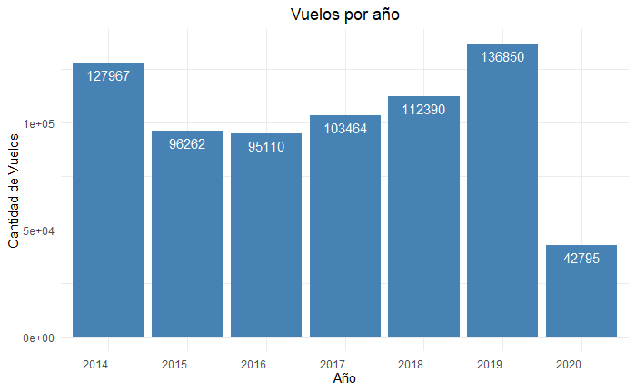

```r
vuelos_coordenadas %>%
  filter(Tipo_de_movimiento == "Aterrizaje") %>%
  ggplot(
    aes(x = Anio)
    ) +
  geom_bar(position = position_dodge(), fill = "steelblue") +
  geom_text(aes(label=..count..),stat='count',position=position_dodge(0.9),vjust=1.6, color="white") +
  labs(fill = "Tipo de Movimiento", x = "Año", y = "Cantidad de Vuelos") +
  ggtitle("Vuelos por año") +
  theme_minimal() +
  theme(axis.text.x = element_text(angle = 0, vjust = 0.3, hjust = 1), plot.title = element_text(hjust = 0.5))
```

Para entender un poco mejor la dinámica de los vuelos durante el año, veamos como es el comportamiento en cada uno de los meses Empecemos por el dataframe del 2021:

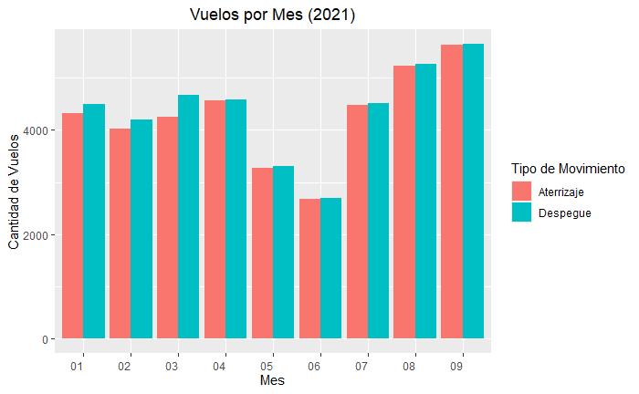

```r
#Primero separamos la columna fecha en otras 3 columnas con el día, mes y año.
vuelos_2021$Dia = str_split_fixed(vuelos_2021$Fecha, "/", 3)[,1]
vuelos_2021$Mes = str_split_fixed(vuelos_2021$Fecha, "/", 3)[,2]
vuelos_2021$Anio = str_split_fixed(vuelos_2021$Fecha, "/", 3)[,3]

ggplot(vuelos_2021,
       aes(x = Mes , fill = Tipo.de.Movimiento, )) +
  geom_bar(position = position_dodge()) +
  labs(fill = "Tipo de Movimiento", x = "Mes", y = "Cantidad de Vuelos") +
  ggtitle("Vuelos por Mes (2021)") +
  theme(axis.text.x = element_text(angle = 0, vjust = 0.3, hjust = 1), plot.title = element_text(hjust = 0.5))
```

Podemos observar que hubo en general menos viajes en mayo y junio del 2021. Esto puede deberse a que en esos meses se produjo un pico en la cantidad de contagios de COVID-19 en Argentina, por lo que aumentaron fuertemente las restricciones. Por otro lado los años 2020 y 2021 son años atípicos para estudiar cómo varía la cantidad de vuelos a lo largo del año.

Hacemos esto mismo con el 2020:

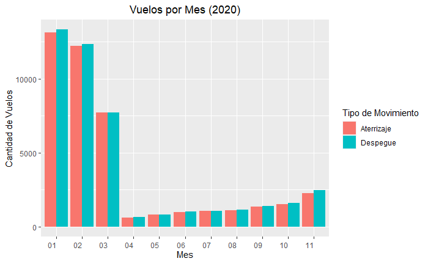

```r
#Me quedo con los vuelos del 2020
vuelos_coordenadas_2020 = vuelos_coordenadas[
  vuelos_coordenadas$Anio == '2020',
  ]


ggplot(vuelos_coordenadas_2020,
       aes(x = Mes , fill = Tipo_de_movimiento )) +
  geom_bar(position = position_dodge()) +
  labs(fill = "Tipo de Movimiento", x = "Mes", y = "Cantidad de Vuelos") +
  ggtitle("Vuelos por Mes (2020)") +
  theme(axis.text.x = element_text(angle = 0, vjust = 0.3, hjust = 1), plot.title = element_text(hjust = 0.5))
```

En este último gráfico se observa un fuerte descenso en la cantidad de vuelos a partir del mes de Abril, que coincide con el inicio de la cuarentena.

Veamos por último el resto de los años en donde todavía no se habia producido la pandemia, para tener idea sobre la magnitud de vuelos en años pre-pandemia. Queremos ver además si se produce un corte tan pronunciado en los vuelos a partir del mes de Abril.

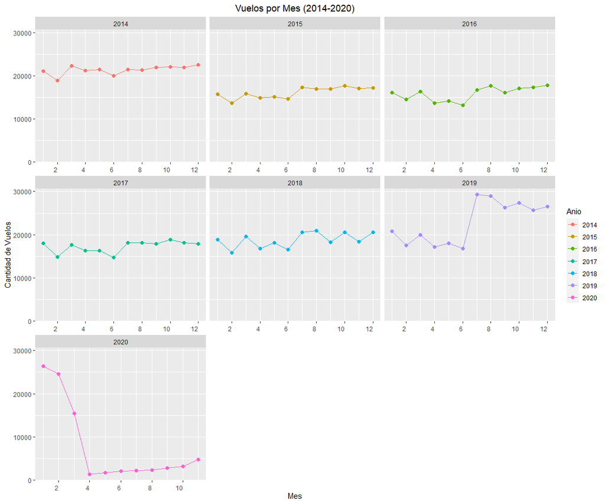

```r
vuelos_coordenadas %>%
  group_by(Anio, Mes) %>%
  mutate(count = n()) %>%
  ggplot(
    aes(x = as.numeric(Mes) , y = count, color = Anio)) +
  geom_point(size = 2) +
  geom_line() +
  labs(fill = "Tipo de Movimiento", x = "Mes", y = "Cantidad de Vuelos") +
  ggtitle("Vuelos por Mes (2014-2020)") +
  theme(axis.text.x = element_text(angle = 0, vjust = 0.3, hjust = 1), plot.title = element_text(hjust = 0.5)) +
  scale_x_continuous(breaks = pretty_breaks()) +
  facet_wrap(~ Anio, scales = "free_x")
```

Podemos notar que la caída abrupta del año 2020 es un caso atípico debido a la pandemia, que no se replica en años anteriores. Por otro lado se puede observar también que en los meses Abril-Mayo-Junio la cantidad de vuelos disminuye en comparación a otros meses. Luego, en el mes de Julio de todos los años anteriores a 2020, se puede notar un incremento en los vuelos en comparación con Junio, que posiblemente esté relacionado con el receso invernal.

Continuando con los análisis de vuelos por mes, y teniendo en cuenta que Buenos Aires posee la mayor cantidad de vuelos por año y por lo tanto la mayor cantidad de observaciones en el dataset, veamos el comportamiento de los vuelos en los meses del año.

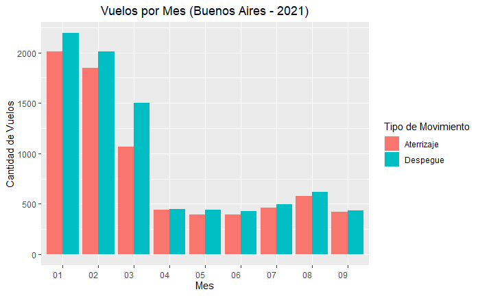

```r
vuelos_2021 %>%
  filter(Provincia_A %in% c("Buenos Aires")) %>%
           ggplot(
                  aes(x = Mes , fill = Tipo.de.Movimiento)) +
           geom_bar(position = position_dodge()) +
           labs(fill = "Tipo de Movimiento", x = "Mes", y = "Cantidad de Vuelos") +
           ggtitle("Vuelos por Mes (Buenos Aires - 2021)") +
           theme(axis.text.x = element_text(angle = 0, vjust = 0.3, hjust = 1), plot.title = element_text(hjust = 0.5))
```

Nuevamente se observa una caída abrupta luego de los meses veraniegos, probablemente debido a el aumento de contagios por COVID-19 y las medidas restrictivas impuestas por el gobierno.

Algo que nos podemos preguntar también es si hay algunos días en donde se suela viajar mas que otros, partiendo desde Buenos Aires:

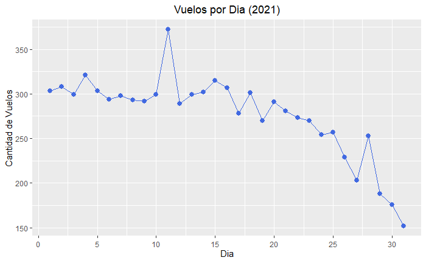

```r
#ploteamos la cantidad de vuelos en cada día de todos los meses, saliendo desde Buenos Aires
vuelos_2021 %>%
  filter(Provincia_A == "Buenos Aires", Tipo.de.Movimiento == "Despegue") %>%
  group_by(Dia) %>%
  summarise(count=n()) %>%
  ggplot(
    aes(x = as.numeric(Dia) , y = count )) +
  geom_line(color = "royalblue") +
  geom_point(color = "royalblue", size = 2.5) +
  labs(fill = "Tipo de Movimiento", x = "Dia", y = "Cantidad de Vuelos") +
  ggtitle("Vuelos por Dia (2021)") +
  theme(axis.text.x = element_text(angle = 0, vjust = 0.3, hjust = 0.5), plot.title = element_text(hjust = 0.5))+
  scale_x_continuous(breaks = pretty_breaks())
```

Podemos ver que a medida que nos acercamos a fin de mes, la cantidad de vuelos cae bastante, ¿Podría esto deberse a que las fechas de cobro suelen ser en general a principio de mes? ¿O será que al tratarse de despegues desde Buenos Aires, lo vuelos relacionados con el turismo re realizan a principio de mes? Por otro lado el dia 31 no podemos tenerlo en cuenta ya que pocos meses tienen 31.

Vamos a analizar ahora la densidad de vuelos en cada una de las provincias:

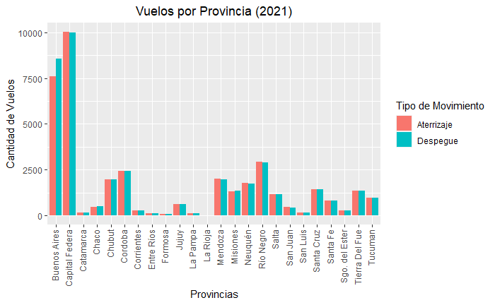

```r
#Corregimos algunas provincias que estaban mal escritas
vuelos_2021$Provincia_A = gsub("Córdoba", "Cordoba", vuelos_2021$Provincia_A)
vuelos_2021$Provincia_A = gsub("Santa cruz", "Santa Cruz", vuelos_2021$Provincia_A)


#ploteamos los vuelos por provincia en el año 2021
ggplot(vuelos_2021,
       aes(x = Provincia_A , fill = Tipo.de.Movimiento, )) +
  geom_bar(position = position_dodge()) +
  labs(fill = "Tipo de Movimiento", x = "Provincias", y = "Cantidad de Vuelos") +
  ggtitle("Vuelos por Provincia (2021)") +
  theme(axis.text.x = element_text(angle = 90, vjust = 0.3, hjust = 1), plot.title = element_text(hjust = 0.5))
```

Se puede observar que como es esperado, la mayoría de los vuelos se producen en Buenos Aires. Algo interesante es que hay una gran cantidad de vuelos en provincias como Mendoza y Chubut que son puntos turísitcos muy importantes. Una provincia que nos sorprendió que tenga una gran cantidad de vuelos es Neuquén. Para ver si es un patrón que se repite a lo largo de los años vamos a graficar la cantidad de vuelos por provincia entre los años 2014-2020.

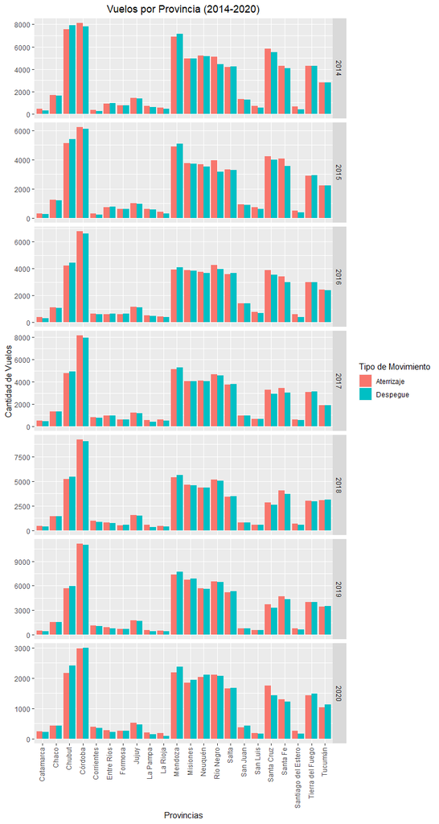

```r
vuelos_coordenadas %>%
  filter(Provincia_origen != "Buenos Aires") %>%
  ggplot(
    aes(x = Provincia_origen , fill = Tipo_de_movimiento)) +
  geom_bar(position = position_dodge()) +
  labs(fill = "Tipo de Movimiento", x = "Provincias", y = "Cantidad de Vuelos") +
  ggtitle("Vuelos por Provincia (2014-2020)") +
  theme(axis.text.x = element_text(angle = 90, vjust = 0.3, hjust = 1), plot.title = element_text(hjust = 0.5)) +
  facet_grid(Anio ~ ., scales = "free_y")
```

Veamos ahora cuales son las ciudades que reciben mayor cantidad de vuelos desde Buenos Aires en el 2021 (Hasta septiembre).

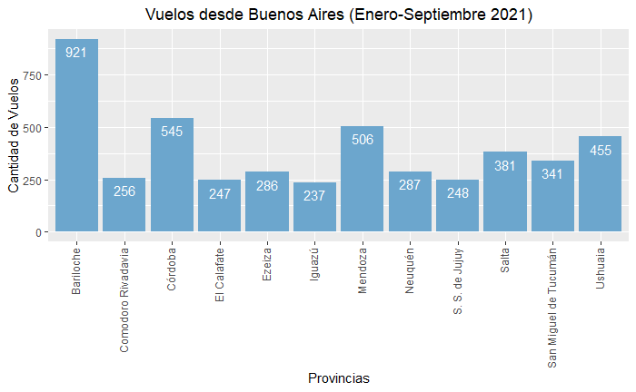

```r
vuelos_2021 %>%
  filter(Tipo.de.Movimiento == "Despegue", Provincia_A == "Buenos Aires") %>%
  filter(Origen_Destino != "AER", Origen_Destino != "FDO") %>%
  group_by(Ciudad_OD) %>%
  mutate(count=n()) %>%
  filter(count>200) %>%
  ggplot(aes(x = Ciudad_OD)) +
  geom_bar(position = position_dodge(), fill = "skyblue3") +
  labs(fill = "Tipo de Movimiento", x = "Provincias", y = "Cantidad de Vuelos") +
  ggtitle("Vuelos desde Buenos Aires (Enero-Septiembre 2021)") +
  theme(axis.text.x = element_text(angle = 90, vjust = 0.3, hjust = 1), plot.title = element_text(hjust = 0.5)) +
  geom_text(aes(label=..count..),stat='count',position=position_dodge(0.9),vjust=1.6, color="white")
```

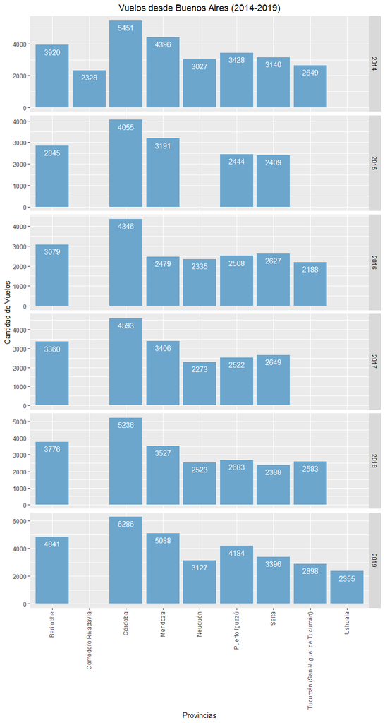

```r
#limpiamos los espacios en blanco de la columna tipo_de_movimiento
vuelos_coordenadas$Tipo_de_movimiento = gsub(' ', '', vuelos_coordenadas$Tipo_de_movimiento, fixed = TRUE)

#ploteamos los vuelos que salen desde buenos aires entre los años 2014 y 2020. Filtramos los destinos con cantidades menores a 2150.
vuelos_coordenadas %>%
  filter(Tipo_de_movimiento == "Despegue", Provincia_origen == "Buenos Aires") %>%
  filter(Provincia_destino != "Buenos Aires") %>%
  group_by(Ciudad_destino, Anio) %>%
  mutate(count=n()) %>%
  filter(count>2150) %>%
  ggplot(aes(x = Ciudad_destino)) +
  geom_bar(position = position_dodge(), fill = "skyblue3") +
  labs(fill = "Tipo de Movimiento", x = "Provincias", y = "Cantidad de Vuelos") +
  ggtitle("Vuelos desde Buenos Aires (2014-2019)") +
  theme(axis.text.x = element_text(angle = 90, vjust = 0.3, hjust = 1), plot.title = element_text(hjust = 0.5)) +
  geom_text(aes(label=..count..),stat='count',position=position_dodge(0.9),vjust=1.6, color="white") +
  facet_grid(Anio ~ ., scales = "free_y")
```

Se puede observar que a diferencia del 2021, en los años anteriores la ciudad mas visitada fue Córdoba con un promedio de 5000 vuelos por año. Por otro lado podemos ver que en el caso de Comodoro Rivadavia la cantidad de vuelos desde Buenos Aires se redujo desde el 2014, en contraposición con el caso de Ushuaia que en 2019 alcanzó su pico de vuelos. Analicemos estos últimos casos por separado:

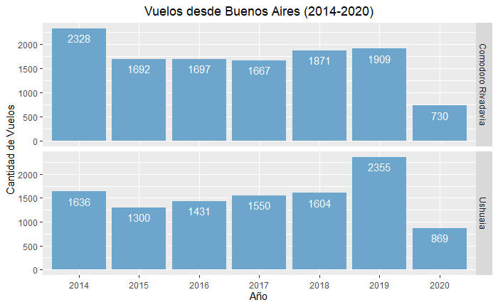

```r
vuelos_coordenadas %>%
  filter(Tipo_de_movimiento == "Despegue", Provincia_origen == "Buenos Aires") %>%
  filter(Ciudad_destino %in% c("Comodoro Rivadavia", "Ushuaia")) %>%
  group_by(Ciudad_destino) %>%
  mutate(count=n()) %>%
  filter(count>2150) %>%
  ggplot(aes(x = Anio)) +
  geom_bar(position = position_dodge(), fill = "skyblue3") +
  labs(x = "Año", y = "Cantidad de Vuelos") +
  ggtitle("Vuelos desde Buenos Aires (2014-2020)") +
  theme(axis.text.x = element_text(angle = 0, vjust = 0.3, hjust = 0.5), plot.title = element_text(hjust = 0.5)) +
  geom_text(aes(label=..count..),stat='count',position=position_dodge(0.9),vjust=1.6, color="white") +
  facet_grid(Ciudad_destino ~ ., scales = "free_y")
```

Se observa entonces lo que decíamos antes, que luego del 2014 la cantidad de vuelos disminuyó, y en contraposición el caso de Ushuaia que tuvo un incremento de vuelos en el 2019.

Podemos analizar con qué tipo de aeronaves se realizan la mayoría de los vuelos en el 2021.

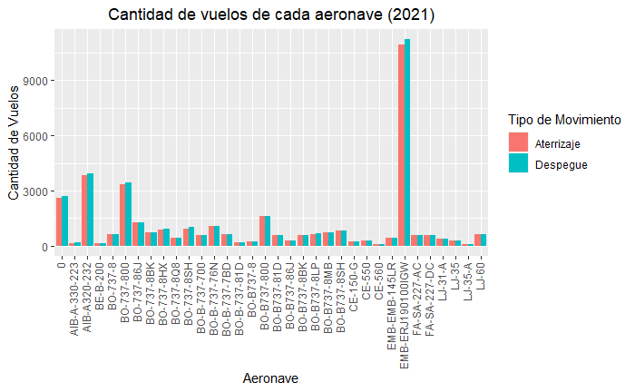

```r
vuelos_2021 %>%
  group_by(Aeronave) %>%
  filter(n() > 200) %>%
  ggplot(
    aes(x = Aeronave , fill = Tipo.de.Movimiento)) +
  geom_bar(position = position_dodge()) +
  labs(fill = "Tipo de Movimiento", x = "Aeronave", y = "Cantidad de Vuelos") +
  ggtitle("Cantidad de vuelos de cada aeronave (2021)") +
  theme(axis.text.x = element_text(angle = 90, vjust = 0.3, hjust = 1), plot.title = element_text(hjust = 0.5)
        )
```

Vemos que la mayoría de vuelos pertenecen a la aeronave “EMB-ERJ190100IGW” que es un tipo de jet.

[figure not shown]

```r
library(imager)
im<-load.image("avion.jpeg")
plot(im, axes = FALSE)
```

Veamos ahora qué aerolíneas utilizan este tipo de Aeronave.

```r
#Filtro por la aeronave "EMB-ERJ190100IGW" y agrupo el dataset por Aeronaves y Aerolíneas
vuelos_2021 %>%
  filter(Aeronave == "EMB-ERJ190100IGW", Aerolinea.Nombre != 0) %>%
  group_by(Aeronave, Aerolinea.Nombre) %>%
  summarise(n()) %>%
  rename("Cantidad de Vuelos" = "n()")
```

| Aeronave | Aerolinea.Nombre | Cantidad de Vuelos |
| --- | --- | --- |
| EMB-ERJ190100IGW | AEROLINEAS ARGENTINAS SA | 22179 |
| EMB-ERJ190100IGW | FB LÍNEAS AÉREAS - FLYBONDI | 2 |
| EMB-ERJ190100IGW | INST SUP ESTUDIOS AERON | 1 |
| EMB-ERJ190100IGW | INTERNATIONAL AERO | 1 |

```r
NA
```

Se puede observar que es una de las principales aeronaves que utiliza Aerolíneas Argentinas.

Veamos ahora qué aerolineas tienen la mayor cantidad de vuelos

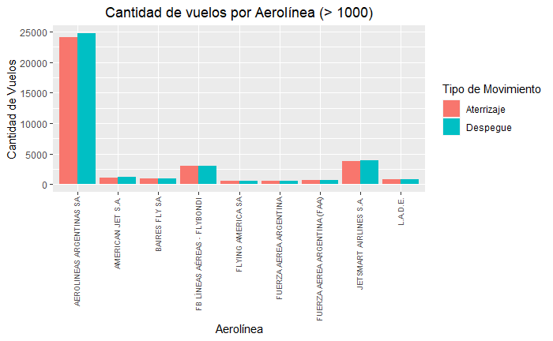

```r
vuelos_2021 %>%
  group_by(Aerolinea.Nombre) %>%
  filter(Aerolinea.Nombre != "0") %>%
  filter(n() > 1000) %>%
  ggplot(
    aes(x = Aerolinea.Nombre , fill = Tipo.de.Movimiento)
    ) +
  geom_bar(position = position_dodge()) +
  labs(fill = "Tipo de Movimiento", x = "Aerolínea", y = "Cantidad de Vuelos") +
  ggtitle("Cantidad de vuelos por Aerolínea (> 1000)") +
  theme(axis.text.x = element_text(angle = 90, vjust = 0.3, hjust = 1, size = 6.5), plot.title = element_text(hjust = 0.5)
        )
```

Vemos en este gráfico como es de esperarse que la mayoría de los vuelos son de Aerolíneas Argentinas, seguido de las aerolíneas low-cost “Jet-Smart Airlines S.A” y “Fly-Bondi”. Algo interesante que notamos es que la aerolínea de low-cost “Flybondi” que tuvo su primer vuelo en 2018, es la tercer aerolínea con más vuelos en la argentina pero con tan solo 5 aviones en su flota! La pregunta que sigue sería entonces: ¿En qué momento se realiza el mantenimiento de los aviones?

Veamos la cantidad de vuelos que realizó “Fly-Bondi” desde su inauguración (2018):

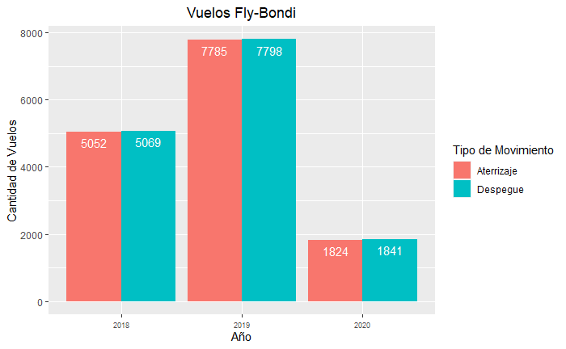

```r
vuelos_coordenadas$Nombre_de_aereolinea = gsub(' ', '', vuelos_coordenadas$Nombre_de_aereolinea, fixed = TRUE)

vuelos_coordenadas %>%
  filter(Nombre_de_aereolinea == "Flybondi") %>%
  ggplot(
    aes(x = Anio, fill = Tipo_de_movimiento)) +
  geom_bar(position = position_dodge()) +
  labs(fill = "Tipo de Movimiento", x = "Año", y = "Cantidad de Vuelos") +
  ggtitle("Vuelos Fly-Bondi") +
geom_text(aes(label=..count..),stat='count',position=position_dodge(0.9),vjust=1.6, color="white") +
  theme(axis.text.x = element_text(angle = 0, vjust = 0.3, hjust = 0.5, size = 6.5), plot.title = element_text(hjust = 0.5)
        )
```

Hacemos ahora un análisis estadístico de las distancias recorridas en cada uno de los meses del año 2021 (Hasta septiembre)

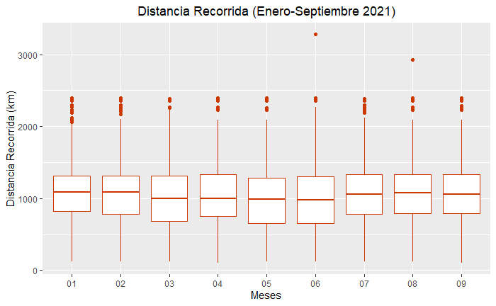

```r
vuelos_2021_sin0 <- vuelos_2021 %>%
  filter(Distancia_Recorrida_km > 100)

vuelos_2021_sin0 %>%
  ggplot(
    aes(x = Mes, y = Distancia_Recorrida_km )) +
  geom_boxplot(color = "orangered3") +
  scale_fill_brewer(palette="Dark2") +
  labs( x = "Meses", y = "Distancia Recorrida (km)") +
  ggtitle("Distancia Recorrida (Enero-Septiembre 2021)") +
  theme(plot.title = element_text(hjust = 0.5))
```

Se observa que en promedio las distancias recorridas rondan los mil kilómetros, y que en el mes de Junio hubo una mayor cantidad de vuelos con recorridos mas cortos.

Grafiquemos ahora un boxplot para las velocidades medias de cada aeronave:

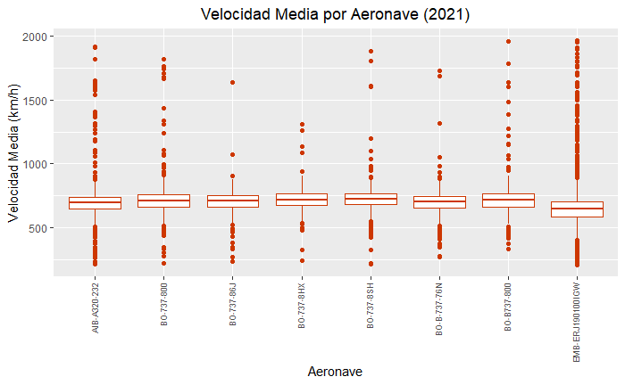

```r
matched %>%
  group_by(Aeronave) %>%
  mutate(count = n()) %>%
  filter(count > 800) %>%
  filter(velocidad_media > 200, velocidad_media < 2000 ) %>%
  filter(Aeronave!= 0) %>%
    ggplot(
    aes(x = Aeronave, y = velocidad_media )) +
  geom_boxplot(color = "orangered3") +
  scale_fill_brewer(palette="Dark2") +
  labs( x = "Aeronave", y = "Velocidad Media (km/h)") +
  ggtitle("Velocidad Media por Aeronave (2021)") +
  theme(plot.title = element_text(hjust = 0.5), axis.text.x = element_text(angle = 90, vjust = 0.3, hjust = 1, size = 6.5) )
```

```r
NA
```

Vemos que las medianas rondan los 700km/h, lo cual tiene sentido en este tipo de aeronaves como los boeings y los jets Embraer, pero aún así creemos que hay una gran cantidad de datos erróneos ya que por ejemplo la velocidad máxima de la Aeronave “EMB-ERJ190100IGW” es de 890km/h y nosotros estamos obteniendo velocidades muy superiores a ese valor. Esto podría deberse a que los tiempo de vuelo o las distancias recorridas no sean las correctas.

Por otro lado, podemos ver qué distancias suelen recorrer las distintas Aeronaves para si existen preferencias a la hora de realizar vuelos de mas larga distancia o viceversa:

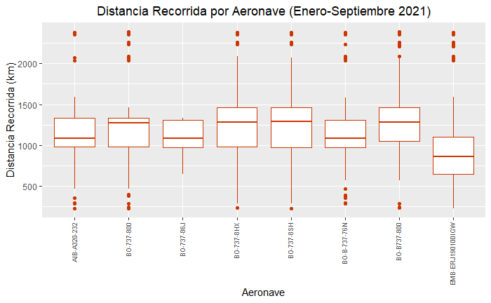

```r
matched %>%
  group_by(Aeronave) %>%
  mutate(count = n()) %>%
  filter(Aeronave != 0) %>%
  filter(count > 800) %>%
  filter(velocidad_media > 200, velocidad_media < 3000 ) %>%
    ggplot(
    aes(x = Aeronave, y = Distancia_Recorrida_km.x )) +
  geom_boxplot(color = "orangered3") +
  scale_fill_brewer(palette="Dark2") +
  labs( x = "Aeronave", y = "Distancia Recorrida (km)") +
  ggtitle("Distancia Recorrida por Aeronave (Enero-Septiembre 2021)") +
  theme(plot.title = element_text(hjust = 0.5), axis.text.x = element_text(angle = 90, vjust = 0.3, hjust = 1, size = 6.5) )
```

Se puede observar que las medianas de cada Aeronave suelen ser bastante similares, en el rango entre los 1000km y 1500km con exepción del “Jet-Embraer 190” que ronda los 850km. Podemos concluir entonces que pareciera ser que no hay una dependencia marcada entre la distancia de los vuelos y las Aeronaves utilizadas.

Veamos ahora los tiempos de vuelos de cada Aerolínea:

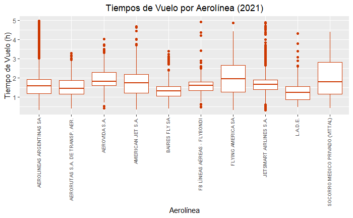

Vemos que la mediana de los tiempos de vuelos de cada aerolínea ronda entre 1h y 2hs, lo cual tiene sentido para vuelos nacionales.